# Project: Data Wrangling and Analysis

#### Test

```python
# looks at all unique names in list of names. checks to see if I missed any values which are obviously not dog names
clean_twitter_archive.name.unique()
```

```
array(['NOT FOUND', 'Walter', 'Scout', 'Kreggory', 'Jimothy',
       'Christoper', 'Lugan', 'Josep', 'Jockson', 'Jeph', 'Carll',
       'Klevin', 'Keet', 'Dave', 'Clybe', 'Gabe', 'Pipsy', 'Bradlay',
       'Churlie', 'Kenneth', 'Clarence', 'Timison', 'Joshwa', 'Genevieve',
       'Fwed', 'Biden', 'Cupcake', 'Reese', 'Philippe', 'Hall', 'Dook',
       'Naphaniel', 'Frank', 'Kial', 'George', 'Olive', 'Calvin', 'Filup',
       'Shaggy', 'Tedrick', 'Stu', 'Erik', 'Cleopatricia', 'Otis',
       'Jiminy', 'Alfie', 'Skittles', 'Ron', 'Torque', 'Bisquick',
       'Jareld', 'Sophie', 'Rusty', 'DayZ', 'Jo', 'Gòrdón', 'Spark',
       'Marvin', 'Kallie', 'Jomathan', 'Maks', 'Timofy', 'Zeek', 'Hanz',
       'Winifred', 'Kevon', 'Banditt', 'Bobb', 'Amélie', 'Ruffles',
       'Lambeau', 'Herald', 'Jaycob', 'Jeremy', 'Chaz', 'Ruby', 'Bernie',
       'Harrison', 'Terrance', 'Tucker', 'Samsom', 'Jaspers', 'Clarq',
       'Ralf', 'Kirk', 'Sully', 'Tessa', 'Dug', 'Saydee', 'Chip',
       'Oliviér', 'Billl', 'Ronduh', 'Kollin', 'Keith', 'Linda', 'Skye',
       'Penny', 'Shawwn', 'Louie', 'Kloey', 'Chester', 'Andru', 'Julio',
       'Zoey', 'Raphael', 'Ben', 'Tommy', 'Liam', 'Randall', 'Winston',
       'Fabio', 'Wally', 'Sandra', 'Butters', 'Daisy', 'Larry', 'Nigel',
       'Peanut', 'Scooter', 'Damon', 'Herb', 'Willy', 'Sam', 'Hank',
       'Koda', 'Paull', 'Edd', 'Phineas', 'Bloo', 'Pluto', 'Ester',
       'Danny', 'Jeffrie', 'Jerry', 'Gin', 'Vincent', 'Traviss', 'Creg',
       'Antony', 'Trigger', 'Mason', 'Andy', 'Maggie', 'Sage',
       'Remington', 'Amy', 'Jett', 'Colby', 'Toby', 'Phred', 'Holly',
       'Anthony', 'Herm', 'Sparky', 'Lola', 'Lou', 'Tanner', 'Penelope',
       'Malcolm', 'Julius', 'Pip', 'Charlie', 'Hammond', 'Scruffers',
       'Alejandro', 'Jax', 'Reginald', 'Baxter', 'JD', 'Marley', 'Oscar',
       'Mark', 'space', 'Dylan', 'Mia', 'Brad', 'Batdog', 'Mojo', 'Gizmo',
       'Patch', 'Tuco', 'just', 'Bubba', 'Bradley', 'Opal', 'Cal',
       'Ridley', 'Snickers', 'Rolf', 'Kreg', 'Pippin', 'Franq', 'Buddy',
       'Jazz', 'light', 'Jackie', 'Darby', 'Taz', 'Scott', 'Caryl',
       'Norman', 'Leonidas', 'Ed', 'Cheryl', 'Jimison', 'Terry', 'Gustaf',
       'Chet', 'Chuckles', 'Schnozz', 'Pumpkin', 'Kenzie', 'Fletcher',
       'Dexter', 'Mac', 'Eve', 'Frankie', 'Django', 'Gerald', 'Bella',
       'Steve', 'Sandy', 'Jeffri', 'Albert', 'Kendall', 'Shnuggles',
       'Pickles', 'Dot', 'Raymond', 'Riley', 'Obie', 'Aiden', 'Acro',
       'Kaiya', 'Lucy', 'Stanley', 'Earl', 'Mitch', 'Bobbay', 'Gus',
       'Henry', 'Bob', 'Kenny', 'life', 'Lennon', 'Chesney', 'Gary',
       'Lenny', 'Jonah', 'Ava', 'Bailey', 'Louis', 'Rodman', 'Jeb',
       'Patrick', 'Rufio', 'Superpup', 'Tedders', 'Laela', 'Mollie',
       'Moe', 'Oliver', 'Zuzu', 'Steven', 'Coops', 'Arnold', 'Reggie',
```

[output cut: 74 more lines]

```
       'Yogi', 'Snicku', 'Romeo', 'Tyr', 'Pancake', 'Iroh', 'Longfellow',
       'Sobe', 'Chef', 'Mauve', 'Bones', 'Ronnie', 'Severus', 'Sonny',
       'Diogi', 'Shooter', 'Zeke', 'Major', 'incredibly', 'Waffles',
       'Stephan', 'Seamus', 'Ito', 'Kyro', 'Craig', 'Augie', 'Halo',
       'Mary', 'Brandi', 'Swagger', 'Bauer', 'Baron', 'Eleanor', 'Chubbs',
       'Alf', 'Akumi', 'Comet', 'Dudley', 'Binky', 'Timber', 'Chloe',
       'Tebow', 'Strudel', 'Ken', 'Eugene', 'Dido', 'Autumn', 'Florence',
       'Tom', 'Wafer', 'Anna', 'Jazzy', 'Howie', 'Flash', 'Sundance',
       'Harlso', 'Duchess', 'Paisley', 'Hobbes', 'Albus', 'Crawford',
       'Cash', 'Pablo', 'Sweet', 'Mo', 'Ike', 'Pilot', 'Pawnd', 'Cupid',
       'Ralphie', 'Boots', 'Kona', 'Brutus', 'Sailer', 'Alexander',
       'Beebop', 'Doobert', 'Lilly', 'Pete', 'Dutch', 'Kuyu', 'Emanuel',
       'Miguel', 'Smiley', 'Eevee', 'Orion', 'Willow', 'Rhino', 'Gidget',
       'Poppy', 'Bronte', 'Gabby', 'Lipton', 'Sunshine', 'Tobi', 'Mookie',
       'Arlo', NaT], dtype=object)
```

#### Tidiness Issue #1

#### Define

1. "df_twitter_archive" timestamp can be separated into date and time
   - each column should observe one value

#### Code

```python
# extracts date from the timestamp column
clean_twitter_archive['posted_date'] = pd.to_datetime(clean_twitter_archive['timestamp']).dt.date
```

```python
# extracts time from the timestamp column
clean_twitter_archive['posted_time'] = pd.to_datetime(clean_twitter_archive['timestamp']).dt.time
```

```python
# looks at column names to get them ready to reorder, checks to see if date and time columns have been added
clean_twitter_archive.columns
```

```
Index(['tweet_id', 'timestamp', 'source', 'text', 'expanded_urls',
       'rating_numerator', 'rating_denominator', 'name', 'doggo', 'floofer',
       'pupper', 'puppo', 'posted_date', 'posted_time'],
      dtype='object')
```

```python
# drops timestamp column as it is now unnecessary
clean_twitter_archive.drop(columns=['timestamp'], axis=1, inplace=True)

clean_twitter_archive.drop(index='timestamp', inplace=True)
```

```python
# reordered columns
clean_twitter_archive = clean_twitter_archive.reindex(columns=['tweet_id', 'posted_date', 'posted_time', 'source', 'text', 'expanded_urls',
       'rating_numerator', 'rating_denominator', 'name', 'doggo', 'floofer',
       'pupper', 'puppo'])
```

#### Test

```python
# checks to see if columns were reordered correctly
clean_twitter_archive.head()
```

|  | tweet_id | posted_date | posted_time | source | text | expanded_urls | rating_numerator | rating_denominator | name | doggo | floofer | pupper | puppo |
| --- | --- | --- | --- | --- | --- | --- | --- | --- | --- | --- | --- | --- | --- |
| 0 | 666020888022790149 | 2015-11-15 | 22:32:08 | <a href="http://twitter.com/download/iphone" r... | Here we have a Japanese Irish Setter. Lost eye... | https://twitter.com/dog_rates/status/666020888... | 8 | 10 | NOT FOUND | None | None | None | None |
| 1 | 666029285002620928 | 2015-11-15 | 23:05:30 | <a href="http://twitter.com/download/iphone" r... | This is a western brown Mitsubishi terrier. Up... | https://twitter.com/dog_rates/status/666029285... | 7 | 10 | NOT FOUND | None | None | None | None |
| 2 | 666033412701032449 | 2015-11-15 | 23:21:54 | <a href="http://twitter.com/download/iphone" r... | Here is a very happy pup. Big fan of well-main... | https://twitter.com/dog_rates/status/666033412... | 9 | 10 | NOT FOUND | None | None | None | None |
| 3 | 666044226329800704 | 2015-11-16 | 00:04:52 | <a href="http://twitter.com/download/iphone" r... | This is a purebred Piers Morgan. Loves to Netf... | https://twitter.com/dog_rates/status/666044226... | 6 | 10 | NOT FOUND | None | None | None | None |
| 4 | 666049248165822465 | 2015-11-16 | 00:24:50 | <a href="http://twitter.com/download/iphone" r... | Here we have a 1949 1st generation vulpix. Enj... | https://twitter.com/dog_rates/status/666049248... | 5 | 10 | NOT FOUND | None | None | None | None |

#### Tidiness Issue #2

#### Define

1. "df_twitter_archive" columns "doggo", "floofer", "pupper", and "puppo" have "None" listed for all values. These columns hold no value and should just be dropped. (Tidiness issue because columns should store actual/useful variables and these columns store nothing).

#### Code

```python
# drops doggo, floofer, pupper, and puppo columns
clean_twitter_archive.drop(columns=['doggo', 'floofer','pupper','puppo'], axis=1, inplace=True)
```

#### Test

```python
# checks to make sure columns were dropped successfully
clean_twitter_archive.info()
```

```
<class 'pandas.core.frame.DataFrame'>
Index: 2057 entries, 0 to 2056
Data columns (total 9 columns):
 #   Column              Non-Null Count  Dtype
---  ------              --------------  -----
 0   tweet_id            2057 non-null   object
 1   posted_date         2057 non-null   object
 2   posted_time         2057 non-null   object
 3   source              2057 non-null   object
 4   text                2057 non-null   object
 5   expanded_urls       2057 non-null   object
 6   rating_numerator    2057 non-null   object
 7   rating_denominator  2057 non-null   object
 8   name                2057 non-null   object
dtypes: object(9)
memory usage: 160.7+ KB
```

#### Tidiness Issue #3

#### Define

1. "df_twitter_archive" can be separated to enhance tidiness into a dataframe with tweet_ids and text, and a dataframe with tweet_id and ratings. Could be even further separated into tweet_id and name, tweet_id and timestamp, tweet_id and url, etc.

#### Code

```python
# makes dataframe of tweet_ids, posted_date, and posted_time
tweet_times = clean_twitter_archive[['tweet_id','posted_date', 'posted_time']].copy()
```

```python
# makes dataframe of tweet_ids and ratings
tweet_ratings = clean_twitter_archive[['tweet_id', 'rating_numerator', 'rating_denominator']].copy()
```

```python
# makes dataframe of tweet_ids and tweet content
tweet_text = clean_twitter_archive[['tweet_id', 'text','name']].copy()
```

```python
# makes dataframe of tweet_ids and source + URL
tweet_urls = clean_twitter_archive[['tweet_id', 'source', 'expanded_urls']].copy()
```

#### Test

```python
# checks to see dataframe was created successfully
tweet_times.head()
```

|  | tweet_id | posted_date | posted_time |
| --- | --- | --- | --- |
| 0 | 666020888022790149 | 2015-11-15 | 22:32:08 |
| 1 | 666029285002620928 | 2015-11-15 | 23:05:30 |
| 2 | 666033412701032449 | 2015-11-15 | 23:21:54 |
| 3 | 666044226329800704 | 2015-11-16 | 00:04:52 |
| 4 | 666049248165822465 | 2015-11-16 | 00:24:50 |

```python
# checks to see dataframe was created successfully
tweet_ratings.head()
```

|  | tweet_id | rating_numerator | rating_denominator |
| --- | --- | --- | --- |
| 0 | 666020888022790149 | 8 | 10 |
| 1 | 666029285002620928 | 7 | 10 |
| 2 | 666033412701032449 | 9 | 10 |
| 3 | 666044226329800704 | 6 | 10 |
| 4 | 666049248165822465 | 5 | 10 |

```python
# checks to see dataframe was created successfully
tweet_text.head()
```

|  | tweet_id | text | name |
| --- | --- | --- | --- |
| 0 | 666020888022790149 | Here we have a Japanese Irish Setter. Lost eye... | NOT FOUND |
| 1 | 666029285002620928 | This is a western brown Mitsubishi terrier. Up... | NOT FOUND |
| 2 | 666033412701032449 | Here is a very happy pup. Big fan of well-main... | NOT FOUND |
| 3 | 666044226329800704 | This is a purebred Piers Morgan. Loves to Netf... | NOT FOUND |
| 4 | 666049248165822465 | Here we have a 1949 1st generation vulpix. Enj... | NOT FOUND |

```python
# checks to see dataframe was created successfully
tweet_urls.head()
```

|  | tweet_id | source | expanded_urls |
| --- | --- | --- | --- |
| 0 | 666020888022790149 | <a href="http://twitter.com/download/iphone" r... | https://twitter.com/dog_rates/status/666020888... |
| 1 | 666029285002620928 | <a href="http://twitter.com/download/iphone" r... | https://twitter.com/dog_rates/status/666029285... |
| 2 | 666033412701032449 | <a href="http://twitter.com/download/iphone" r... | https://twitter.com/dog_rates/status/666033412... |
| 3 | 666044226329800704 | <a href="http://twitter.com/download/iphone" r... | https://twitter.com/dog_rates/status/666044226... |
| 4 | 666049248165822465 | <a href="http://twitter.com/download/iphone" r... | https://twitter.com/dog_rates/status/666049248... |

## Create Master DataFrame

#### Define

According to rules of tidy data, we also need a tidy master dataframe.

#### Code

```python
# merges clean dataframes into one master dataframe
master_tweet_df = clean_twitter_archive.merge(clean_image_predictions, on='tweet_id')
master_tweet_df = master_tweet_df.merge(clean_api_tweets, on='tweet_id')
```

#### Test

```python
# checks to see master dataframe was created successfully
master_tweet_df
```

|  | tweet_id | posted_date | posted_time | source | text | expanded_urls | rating_numerator | rating_denominator | name | jpg_url | ... | prediction_confidence_1 | prediction_1_is_breed | breed_prediction_2 | prediction_confidence_2 | prediction_2_is_breed | breed_prediction_3 | prediction_confidence_3 | prediction_3_is_breed | retweet_count | favorite_count |
| --- | --- | --- | --- | --- | --- | --- | --- | --- | --- | --- | --- | --- | --- | --- | --- | --- | --- | --- | --- | --- | --- |
| 0 | 666020888022790149 | 2015-11-15 | 22:32:08 | <a href="http://twitter.com/download/iphone" r... | Here we have a Japanese Irish Setter. Lost eye... | https://twitter.com/dog_rates/status/666020888... | 8 | 10 | NOT FOUND | https://pbs.twimg.com/media/CT4udn0WwAA0aMy.jpg | ... | 0.465074 | True | collie | 0.156665 | True | shetland_sheepdog | 0.061428 | True | 427 | 2315 |
| 1 | 666029285002620928 | 2015-11-15 | 23:05:30 | <a href="http://twitter.com/download/iphone" r... | This is a western brown Mitsubishi terrier. Up... | https://twitter.com/dog_rates/status/666029285... | 7 | 10 | NOT FOUND | https://pbs.twimg.com/media/CT42GRgUYAA5iDo.jpg | ... | 0.506826 | True | miniature_pinscher | 0.074192 | True | rhodesian_ridgeback | 0.072010 | True | 39 | 115 |
| 2 | 666033412701032449 | 2015-11-15 | 23:21:54 | <a href="http://twitter.com/download/iphone" r... | Here is a very happy pup. Big fan of well-main... | https://twitter.com/dog_rates/status/666033412... | 9 | 10 | NOT FOUND | https://pbs.twimg.com/media/CT4521TWwAEvMyu.jpg | ... | 0.596461 | True | malinois | 0.138584 | True | bloodhound | 0.116197 | True | 36 | 101 |
| 3 | 666044226329800704 | 2015-11-16 | 00:04:52 | <a href="http://twitter.com/download/iphone" r... | This is a purebred Piers Morgan. Loves to Netf... | https://twitter.com/dog_rates/status/666044226... | 6 | 10 | NOT FOUND | https://pbs.twimg.com/media/CT5Dr8HUEAA-lEu.jpg | ... | 0.408143 | True | redbone | 0.360687 | True | miniature_pinscher | 0.222752 | True | 117 | 249 |
| 4 | 666049248165822465 | 2015-11-16 | 00:24:50 | <a href="http://twitter.com/download/iphone" r... | Here we have a 1949 1st generation vulpix. Enj... | https://twitter.com/dog_rates/status/666049248... | 5 | 10 | NOT FOUND | https://pbs.twimg.com/media/CT5IQmsXIAAKY4A.jpg | ... | 0.560311 | True | rottweiler | 0.243682 | True | doberman | 0.154629 | True | 37 | 90 |
| ... | ... | ... | ... | ... | ... | ... | ... | ... | ... | ... | ... | ... | ... | ... | ... | ... | ... | ... | ... | ... | ... |
| 1820 | 838561493054533637 | 2017-03-06 | 01:26:54 | <a href="http://twitter.com/download/iphone" r... | This is Walter. His owner has been watching al... | https://twitter.com/dog_rates/status/838561493... | 13 | 10 | Walter | https://pbs.twimg.com/media/C6MrOsEXQAENOds.jpg | ... | 0.216562 | True | doormat | 0.139994 | False | dalmatian | 0.132820 | True | 1242 | 10387 |
| 1821 | 838916489579200512 | 2017-03-07 | 00:57:32 | <a href="http://twitter.com/download/iphone" r... | RT @KibaDva: I collected all the good dogs!! 1... | https://twitter.com/KibaDva/status/83890598062... | 15 | 10 | NOT FOUND | https://pbs.twimg.com/media/C6RkiQZUsAAM4R4.jpg | ... | 0.993651 | False | monitor | 0.001406 | False | envelope | 0.001093 | False | 31 | 0 |
| 1822 | 838921590096166913 | 2017-03-07 | 01:17:48 | <a href="http://twitter.com/download/iphone" r... | This is Arlo. He's officially the king of snow... | https://twitter.com/dog_rates/status/838921590... | 13 | 10 | Arlo | https://pbs.twimg.com/media/C6Ryuf7UoAAFX4a.jpg | ... | 0.664538 | True | brabancon_griffon | 0.170451 | True | yorkshire_terrier | 0.087824 | True | 1880 | 10542 |
| 1823 | 839239871831150596 | 2017-03-07 | 22:22:32 | <a href="http://twitter.com/download/iphone" r... | This is Odie. He's big. 13/10 would attempt to... | https://twitter.com/dog_rates/status/839239871... | 13 | 10 | Odie | https://pbs.twimg.com/media/C6WUNadWYAAPxHv.jpg | ... | 0.927021 | True | newfoundland | 0.050009 | True | saint_bernard | 0.010728 | True | 6008 | 25516 |
| 1824 | 839290600511926273 | 2017-03-08 | 01:44:07 | <a href="http://twitter.com/download/iphone" r... | RT @alexmartindawg: THE DRINK IS DR. PUPPER 10... | https://twitter.com/alexmartindawg/status/8392... | 10 | 10 | NOT FOUND | https://pbs.twimg.com/media/C6XBt9XXEAEEW9U.jpg | ... | 0.670892 | False | monitor | 0.101565 | False | screen | 0.075306 | False | 135 | 0 |

1825 rows × 22 columns

## Store new data

```python
# saves master dataframe into csv file
master_tweet_df.to_csv('twitter_archive_master.csv')
```

# Analyzing and Visualizing Data

```python
master_tweet_df.info()
```

```
<class 'pandas.core.frame.DataFrame'>
Int64Index: 1825 entries, 0 to 1824
Data columns (total 22 columns):
 #   Column                   Non-Null Count  Dtype
---  ------                   --------------  -----
 0   tweet_id                 1825 non-null   object
 1   posted_date              1825 non-null   object
 2   posted_time              1825 non-null   object
 3   source                   1825 non-null   object
 4   text                     1825 non-null   object
 5   expanded_urls            1825 non-null   object
 6   rating_numerator         1825 non-null   object
 7   rating_denominator       1825 non-null   object
 8   name                     1825 non-null   object
 9   jpg_url                  1825 non-null   object
 10  img_num                  1825 non-null   int64
 11  breed_prediction_1       1825 non-null   object
 12  prediction_confidence_1  1825 non-null   float64
 13  prediction_1_is_breed    1825 non-null   bool
 14  breed_prediction_2       1825 non-null   object
 15  prediction_confidence_2  1825 non-null   float64
 16  prediction_2_is_breed    1825 non-null   bool
 17  breed_prediction_3       1825 non-null   object
 18  prediction_confidence_3  1825 non-null   float64
 19  prediction_3_is_breed    1825 non-null   bool
 20  retweet_count            1825 non-null   int64
 21  favorite_count           1825 non-null   int64
dtypes: bool(3), float64(3), int64(3), object(13)
memory usage: 290.5+ KB
```

## Insight #1, Visualization #1 -

How often were the breed predictions from the images actual dog breeds?

```python
predictions_1 = master_tweet_df['prediction_1_is_breed'].value_counts()
predictions_2 = master_tweet_df['prediction_2_is_breed'].value_counts()
predictions_3 = master_tweet_df['prediction_3_is_breed'].value_counts()
```

```python
# creates data frame of series above
df_predictions_1 = pd.DataFrame(predictions_1)
df_predictions_1 = df_predictions_1.transpose().reset_index()
df_predictions_1.columns = ['prediction_number', 'True', 'False']
df_predictions_1.info()
```

```
<class 'pandas.core.frame.DataFrame'>
RangeIndex: 1 entries, 0 to 0
Data columns (total 3 columns):
 #   Column             Non-Null Count  Dtype
---  ------             --------------  -----
 0   prediction_number  1 non-null      object
 1   True               1 non-null      int64
 2   False              1 non-null      int64
dtypes: int64(2), object(1)
memory usage: 152.0+ bytes
```

```python
df_predictions_2 = pd.DataFrame(predictions_2)
df_predictions_2 = df_predictions_2.transpose().reset_index()
df_predictions_2.columns = ['prediction_number', 'True', 'False']
df_predictions_2.info()
```

```
<class 'pandas.core.frame.DataFrame'>
RangeIndex: 1 entries, 0 to 0
Data columns (total 3 columns):
 #   Column             Non-Null Count  Dtype
---  ------             --------------  -----
 0   prediction_number  1 non-null      object
 1   True               1 non-null      int64
 2   False              1 non-null      int64
dtypes: int64(2), object(1)
memory usage: 152.0+ bytes
```

```python
df_predictions_3 = pd.DataFrame(predictions_3)
df_predictions_3 = df_predictions_3.transpose().reset_index()
df_predictions_3.columns = ['prediction_number', 'True', 'False']
df_predictions_3.info()
```

```
<class 'pandas.core.frame.DataFrame'>
RangeIndex: 1 entries, 0 to 0
Data columns (total 3 columns):
 #   Column             Non-Null Count  Dtype
---  ------             --------------  -----
 0   prediction_number  1 non-null      object
 1   True               1 non-null      int64
 2   False              1 non-null      int64
dtypes: int64(2), object(1)
memory usage: 152.0+ bytes
```

```python
prediction_outcomes = df_predictions_1.append(df_predictions_2)
```

```python
prediction_outcomes = prediction_outcomes.append(df_predictions_3)
```

```python
# full dataframe created of the three predictions and the outcomes
prediction_outcomes
```

|  | prediction_number | True | False |
| --- | --- | --- | --- |
| 0 | prediction_1_is_breed | 1333 | 492 |
| 0 | prediction_2_is_breed | 1350 | 475 |
| 0 | prediction_3_is_breed | 1307 | 518 |

```python
prediction_1_ratio = (1333/(1333+492)) * 100
print(f'Prediction 1 correctly guessed a breed {prediction_1_ratio}% of the time.')
```

```
Prediction 1 correctly guessed a breed 73.04109589041096% of the time.
```

```python
prediction_2_ratio = (1350/(1350+475)) * 100
print(f'Prediction 2 correctly guessed a breed {prediction_1_ratio}% of the time.')
```

[output not shown]

```python
prediction_1_ratio = (1307/(1307+518)) * 100
print(f'Prediction 1 correctly guessed a breed {prediction_1_ratio}% of the time.')
```

[output not shown]

```python
# importing some visualization libraries

%matplotlib inline
import matplotlib.pyplot as plt
import numpy as np
import seaborn as sns
sns.set()
```

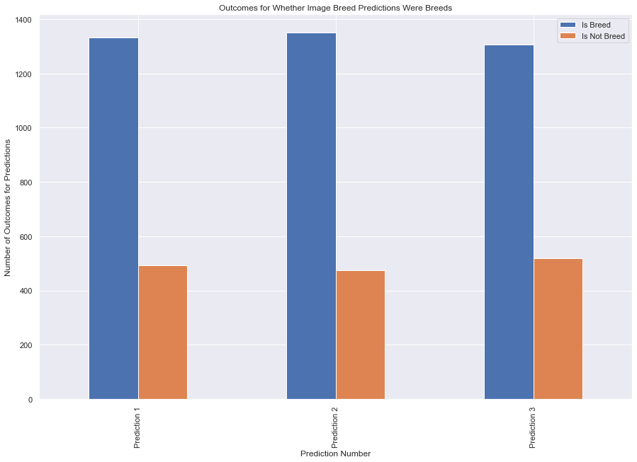

```python
# creates bar graph from prediction outcomes dataframe

ax = prediction_outcomes.plot(kind='bar', figsize=(15,10), title="Outcomes for Whether Image Breed Predictions Were Breeds")
ax.set_ylabel("Number of Outcomes for Predictions")
ax.set_xlabel("Prediction Number")
ax.set_xticklabels(["Prediction 1", "Prediction 2", "Prediction 3"])
ax.legend(labels=['Is Breed', 'Is Not Breed']);
```

As seen above, the breed predictions from the images (predictions 1, 2, and 3) all had a similar ratio of outcomes of whether the dog breed prediction was a breed. The piece of data used for this analysis and visualization was the "prediction_outcomes" dataframe which was created and cleaned in the cells above.